# Analisis Performa Kategori Film Database Sakila

Inesta Salfina Salsa Bella

2026-05-20

### Persamaan Matematika: Analisis Pendapatan per Kategori

Dalam mengevaluasi performa bisnis dari setiap kategori film pada visualisasi di atas, metrik utama yang kita gunakan adalah Total Frekuensi Sewa, Total Pendapatan, dan Rata-rata Pendapatan keseluruhan. Untuk melihat bagaimana total pendapatan sebuah kategori terbentuk dari frekuensi sewa, sekaligus mengukur performa deviasinya terhadap nilai rata-rata secara statistik, kita dapat merangkumnya menggunakan satu persamaan identitas yang komprehensif. Persamaan matematisnya dirumuskan sebagai berikut:

$$P_i = (S_i \times \bar{H}_i) = \bar{P} +
D_i$$

**Keterangan Variabel:**

- $P_i$ mewakili **Total Pendapatan** aktual untuk kategori $i$.
- $S_i$ mewakili **Total Frekuensi Sewa** untuk kategori $i$.
- $\bar{H}_i$ mewakili **Rata-rata Harga Sewa** per judul di kategori $i$. (Ini adalah faktor pengali tak kasat mata yang menjembatani hubungan antara frekuensi sewa dengan total pendapatan).
- $\bar{P}$ mewakili **Rata-rata Pendapatan Keseluruhan** dari semua kategori (digunakan sebagai nilai tengah atau 0 pada visualisasi performa).
- $D_i$ mewakili **Deviasi** atau selisih pendapatan kategori $i$ dari nilai rata-rata ($\bar{P}$). Nilai $D_i$ inilah yang menentukan panjang dan arah bar (positif/negatif) pada grafik evaluasi performa.

## 1. Deskripsi Insight

Laporan ini menggunakan dataset **Sakila** untuk menganalisis performa bisnis dari berbagai kategori film. Analisis ini berfokus pada membandingkan tingkat popularitas (**Total Frekuensi Sewa**) dengan tingkat profitabilitas (**Total Pendapatan USD**) dari setiap kategori film di database Sakila. Insight ini sangat menarik karena membantu kita mengidentifikasi apakah kategori film yang paling sering disewa secara konsisten menghasilkan keuntungan finansial terbesar, atau justru ada kategori yang jarang disewa namun menyumbang pendapatan tinggi (misalnya karena denda keterlambatan atau harga sewa yang berbeda).

## 2. Memuat library yang dibutuhkan

```r
library(DBI)
library(odbc)
library(ggplot2)
library(tidyr)
library(dplyr)
library(ggrepel)
```

## 3. Koneksikan dengan SQL

```r
con2 = dbConnect(odbc(), Driver = "MySQL ODBC 8.0 ANSI Driver",
                 Server = "127.0.0.1", UID = "root", PWD = "1234", Port = 3306,
                 Database = "sakila")
```

## 4. Ekstraksi Data

```sql
SELECT
    c.name AS Kategori,
    COUNT(r.rental_id) AS Total_Sewa,
    SUM(p.amount) AS Total_Pendapatan
  FROM category c
  JOIN film_category fc ON c.category_id = fc.category_id
  JOIN inventory i ON fc.film_id = i.film_id
  JOIN rental r ON i.inventory_id = r.inventory_id
  JOIN payment p ON r.rental_id = p.rental_id
  GROUP BY c.name
  ORDER BY Total_Pendapatan DESC;
```

## 5. Visualisasi Data

### a. Perbandingan total sewa dan Pendapatan per kategori

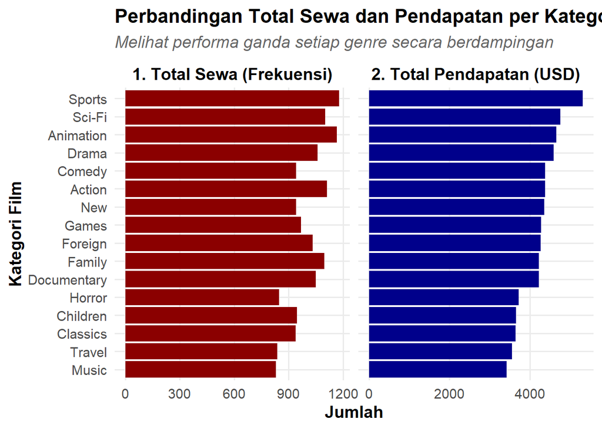

```r
data_kategori$Total_Sewa <- as.numeric(data_kategori$Total_Sewa)
data_kategori$Total_Pendapatan <- as.numeric(data_kategori$Total_Pendapatan)

data_kategori$Kategori <- factor(data_kategori$Kategori,
                                 levels = data_kategori$Kategori[order(data_kategori$Total_Pendapatan)])

data_gabungan <- data_kategori %>%
  pivot_longer(cols = c("Total_Sewa", "Total_Pendapatan"),
               names_to = "Metrik",
               values_to = "Nilai")

data_gabungan$Metrik <- ifelse(data_gabungan$Metrik == "Total_Sewa",
                               "1. Total Sewa (Frekuensi)",
                               "2. Total Pendapatan (USD)")

ggplot(data_gabungan, aes(x = Kategori, y = Nilai, fill = Metrik)) +
  geom_col(show.legend = FALSE) +
  coord_flip() +
  facet_wrap(~ Metrik, scales = "free_x") + # Perintah sakti untuk membelah kanan-kiri
  scale_fill_manual(values = c("1. Total Sewa (Frekuensi)" = "darkred",
                               "2. Total Pendapatan (USD)" = "darkblue")) +
  labs(
    title = "Perbandingan Total Sewa dan Pendapatan per Kategori",
    subtitle = "Melihat performa ganda setiap genre secara berdampingan",
    x = "Kategori Film",
    y = "Jumlah"
  ) +
  theme_minimal(base_size = 14) +
  theme(
    plot.title = element_text(face = "bold", size = 16, color = "black"),
    plot.subtitle = element_text(face = "italic", color = "gray40"),
    strip.text = element_text(face = "bold", size = 14, color = "black"), # Memperbesar teks judul tiap belahan
    axis.title = element_text(face = "bold"),
    panel.grid.minor = element_blank()
  )
```

### Analisis Visualisasi 1

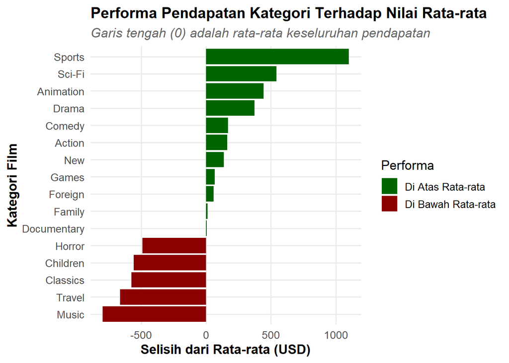

```r
rata_pendapatan <- mean(as.numeric(data_kategori$Total_Pendapatan))
data_kategori$Status <- ifelse(as.numeric(data_kategori$Total_Pendapatan) >= rata_pendapatan,
                               "Di Atas Rata-rata", "Di Bawah Rata-rata")

ggplot(data_kategori, aes(x = reorder(Kategori, Total_Pendapatan),
                          y = as.numeric(Total_Pendapatan) - rata_pendapatan,
                          fill = Status)) +
  geom_col() +
  coord_flip() +
  scale_fill_manual(values = c("Di Atas Rata-rata" = "darkgreen", "Di Bawah Rata-rata" = "darkred")) +
  labs(
    title = "Performa Pendapatan Kategori Terhadap Nilai Rata-rata",
    subtitle = "Garis tengah (0) adalah rata-rata keseluruhan pendapatan",
    x = "Kategori Film",
    y = "Selisih dari Rata-rata (USD)",
    fill = "Performa"
  ) +
  theme_minimal(base_size = 13) +
  theme(
    plot.title = element_text(face = "bold", size = 15, color = "black"),
    plot.subtitle = element_text(face = "italic", color = "gray40"),
    axis.title = element_text(face = "bold"),
    panel.grid.minor = element_blank()
  )
```

### Analisis Visualisasi 2

[output not shown]

## 6. Interpretasi Hasil Visualisasi dan Analisis Data

Ketimpangan antara frekuensi sewa dan total pendapatan pada grafik ini memberikan petunjuk kuat mengenai perbedaan margin keuntungan atau harga sewa rata-rata antargenre film. Kategori Comedy, misalnya, memperlihatkan tingkat efisiensi bisnis yang sangat baik. Mengingat jumlah penyewaannya tidak terlalu tinggi namun mampu mendatangkan pendapatan yang besar, hal ini mengindikasikan bahwa film-film komedi kemungkinan dipatok dengan tarif dasar yang lebih mahal. Selain itu, ada kemungkinan pelanggan sering terlambat mengembalikan film bergenre ini, sehingga toko mendapat pemasukan tambahan dari uang denda. Sebaliknya, tingginya minat pelanggan pada genre seperti Action, Family, Documentary ternyata tidak menghasilkan pendapatan yang maksimal. Fenomena ini mengisyaratkan bahwa film-film pada kategori tersebut disewakan dengan harga yang lebih murah atau sering dijadikan objek promosi, seperti diskon khusus film keluarga di akhir pekan. Karena genre-genre ini berfungsi kuat sebagai penarik pengunjung, manajemen sebaiknya mempertahankan harga murah tersebut sebagai pancingan, agar pelanggan tertarik datang dan menyewa judul lain dari genre yang marginnya lebih tinggi. Sementara itu, untuk kategori Sports yang secara absolut mendominasi kedua metrik, manajemen wajib memastikan ketersediaan stok fisiknya selalu terjaga karena genre ini terbukti menjadi tulang punggung pemasukan utama Sakila. Di sisi lain, performa pada kategori Horror, Children, Classics, Travel, dan Music menjadi sinyal jelas akan rendahnya minat pasar terhadap dokumentasi musik dan perjalanan. Manajemen sebaiknya menghentikan sementara pengadaan judul baru untuk kedua kategori ini, dan memutar stok yang sudah ada melalui program bundling agar inventaris tidak menumpuk.

Pada grafik ini memberikan panduan yang sangat jelas bagi manajemen Sakila terkait prioritas investasi ketersediaan stok film. Beradanya kategori Sports dan Sci-Fi di puncak performa dengan selisih positif yang sangat besar menegaskan bahwa keduanya adalah pilar utama penopang keuangan toko. Tingginya angka ini menandakan keuntungan yang tinggi dari kedua genre tersebut. Oleh karena itu, manajemen sangat disarankan untuk memprioritaskan anggaran belanja guna memperbanyak variasi judul pada kategori-kategori di zona hijau ini. Khusus untuk kategori Documentary yang posisinya nyaris impas dengan garis rata-rata, toko cukup mengelola stok yang sudah ada tanpa perlu melakukan penambahan koleksi. Di sisi lain, kelima kategori di zona merah merupakan area evaluasi yang membebani pendapatan secara keseluruhan. Kekurangan pada Music dan Travel menjadi bukti nyata bahwa pelanggan kurang meminati konten berbentuk dokumentasi konser musik atau perjalana, pada genre ini kemungkinan besar lebih banyak menganggur di rak toko dan berisiko menjadi dead stock. Sebagai langkah efisiensi operasional, manajemen sebaiknya menyetop sementara pengadaan judul baru untuk kelima kategori di zona merah ini. Untuk memaksimalkan nilai dari stok kaset lama yang sudah telanjur menumpuk, toko dapat menerapkan strategi paket promosi (bundling), misalnya dengan meminjamkan satu film bergenre Music atau Travel secara gratis kepada pelanggan yang menyewa dua judul film laris dari kategori penopang utama seperti Sports atau Sci-Fi.